# skin color and discrimination summary

xu

05 January, 2021

## blood sample summary

```
## data_blood %>% dplyr::mutate_all(as.factor)
##
##  7  Variables      2492  Observations
## ------------------------------------------------------------------------------------------------------------------------------------------------
## color_byinterviewer
##        n  missing distinct
##     2214      278        3
##
## Value          White DarkBlack  LightMed
## Frequency       1579       223       412
## Proportion     0.713     0.101     0.186
## ------------------------------------------------------------------------------------------------------------------------------------------------
## lowbirthweight
##        n  missing distinct
##     2483        9        2
##
## Value          0     1
## Frequency   2225   258
## Proportion 0.896 0.104
## ------------------------------------------------------------------------------------------------------------------------------------------------
## high_lowbirth
##        n  missing distinct
##     2483        9        2
##
## Value          0     1
## Frequency   1934   549
## Proportion 0.779 0.221
## ------------------------------------------------------------------------------------------------------------------------------------------------
## discrim1
##        n  missing distinct
##     2446       46       15
##
## lowest : 0  1  2  3  4 , highest: 10 11 12 13 14
##
## Value          0     1     2     3     4     5     6     7     8     9    10    11    12    13    14
## Frequency    389   311   347   323   324   300   162   104    80    46    30    16     8     4     2
## Proportion 0.159 0.127 0.142 0.132 0.132 0.123 0.066 0.043 0.033 0.019 0.012 0.007 0.003 0.002 0.001
## ------------------------------------------------------------------------------------------------------------------------------------------------
## discrim2
##        n  missing distinct
```

[output cut: 13 more lines]

```
##
## Value          0     1     2     3     4     5     6
## Frequency   1214   631   286   172    86    45    10
## Proportion 0.497 0.258 0.117 0.070 0.035 0.018 0.004
## ------------------------------------------------------------------------------------------------------------------------------------------------
## totdiscrim2
##        n  missing distinct
##     2390      102        7
##
## lowest : 0 1 2 3 4, highest: 2 3 4 5 6
##
## Value          0     1     2     3     4     5     6
## Frequency   1990   155    95    75    43    24     8
## Proportion 0.833 0.065 0.040 0.031 0.018 0.010 0.003
## ------------------------------------------------------------------------------------------------------------------------------------------------
```

## whole sample and blood sample plot

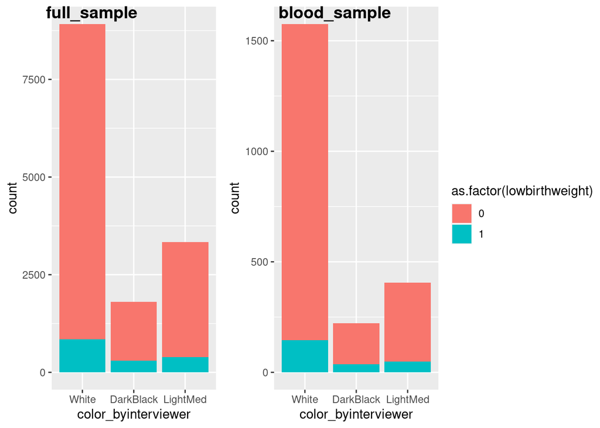

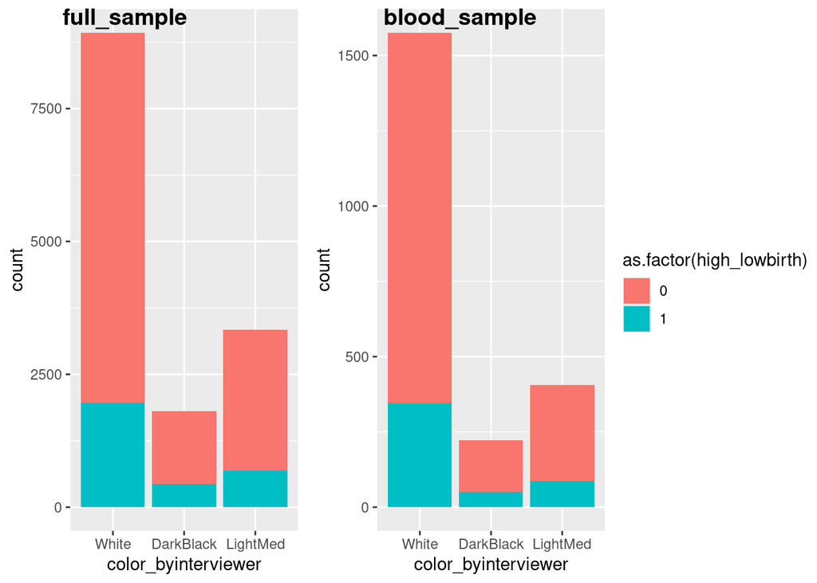

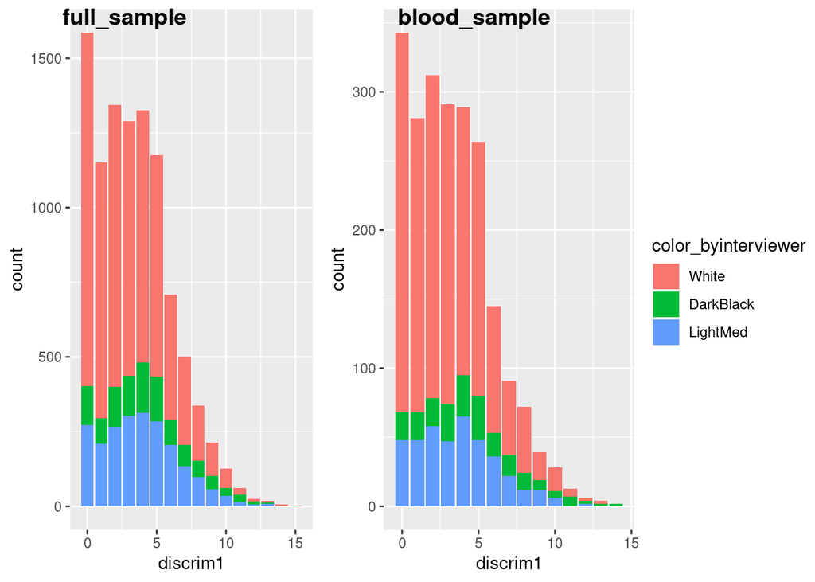

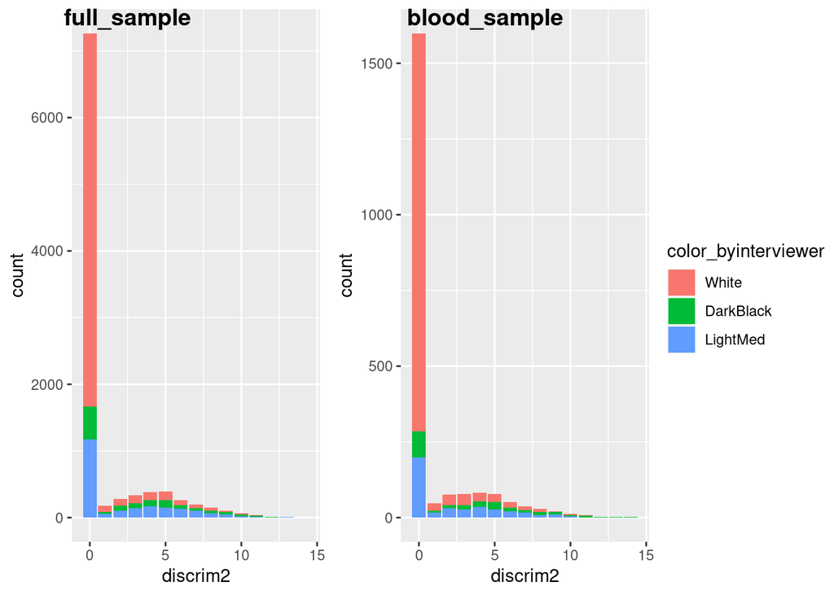

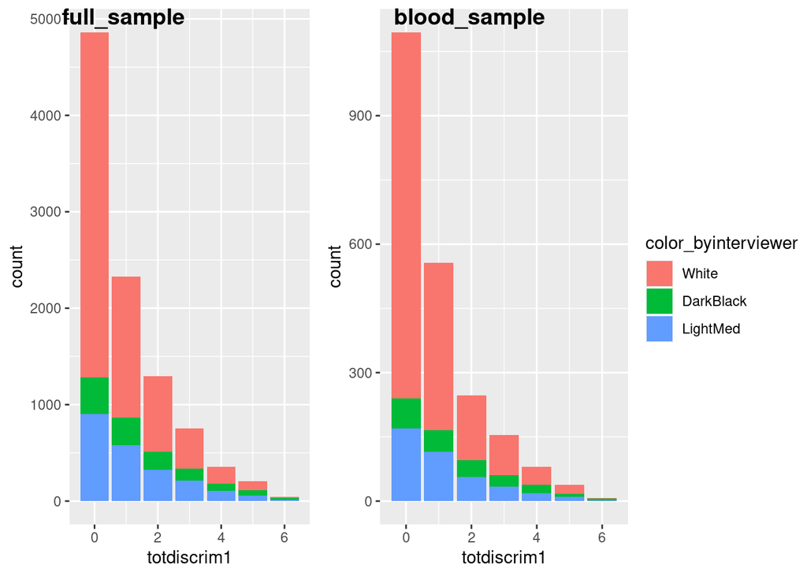

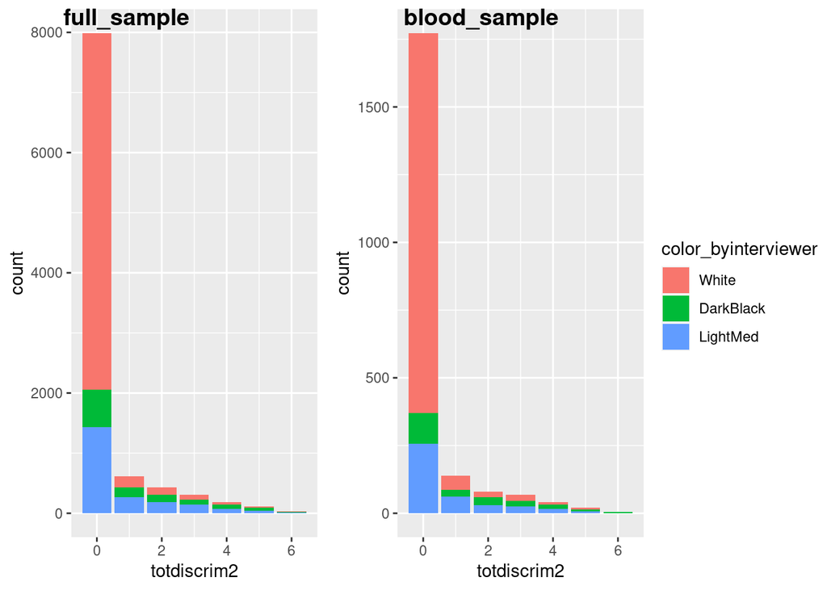

## whole sample White DarkBlack and White LightMed 2 sample Wilcoxon test p value

```
##                     discrim1      discrim2  totdiscrim1   totdiscrim2
## White_DarkBlack 4.527503e-30 2.524212e-264 2.677449e-53 2.927250e-252
## White_LightMed  1.403525e-27 2.797452e-247 9.380546e-33 6.295331e-209
```

## whole sample White DarkBlack and White LightMed 2 sample chisquare test p value

```
##                 lowbirthweight high_lowbirth
## White_DarkBlack   3.721387e-19    0.09283817
## White_LightMed    1.198392e-04    0.08050894
```

## blood sample White DarkBlack and White LightMed 2 sample Wilcoxon test p value

```
##                     discrim1     discrim2  totdiscrim1  totdiscrim2
## White_DarkBlack 3.962746e-11 8.055425e-68 1.049241e-15 1.777400e-66
## White_LightMed  8.419173e-05 9.373250e-59 5.352749e-07 3.112609e-49
```

## blood sample White DarkBlack and White LightMed 2 sample chisquare test p value

```
##                 lowbirthweight high_lowbirth
## White_DarkBlack   0.0009418718     0.9260952
## White_LightMed    0.1348378244     0.8094173
```

## freq distribution of discrim1, discrim2, totdiscrim1, totdiscrim2, discrimwhy for blood sample

### discrim1 is the sum of 5 types of discrimination H5MN5[A-E]

- H5MN5[A-E], each range of 0:3, never(0), rarely(1), sometimes(2), often(3)

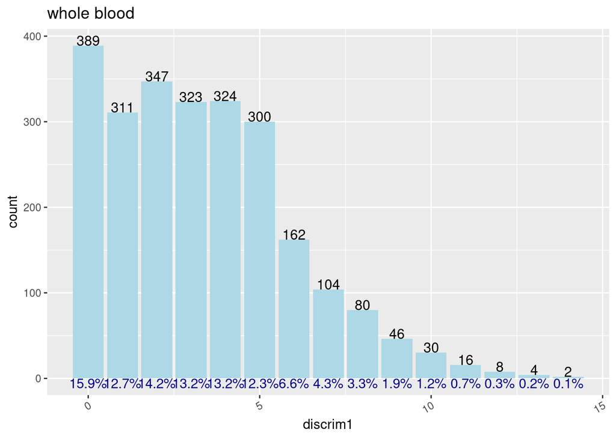

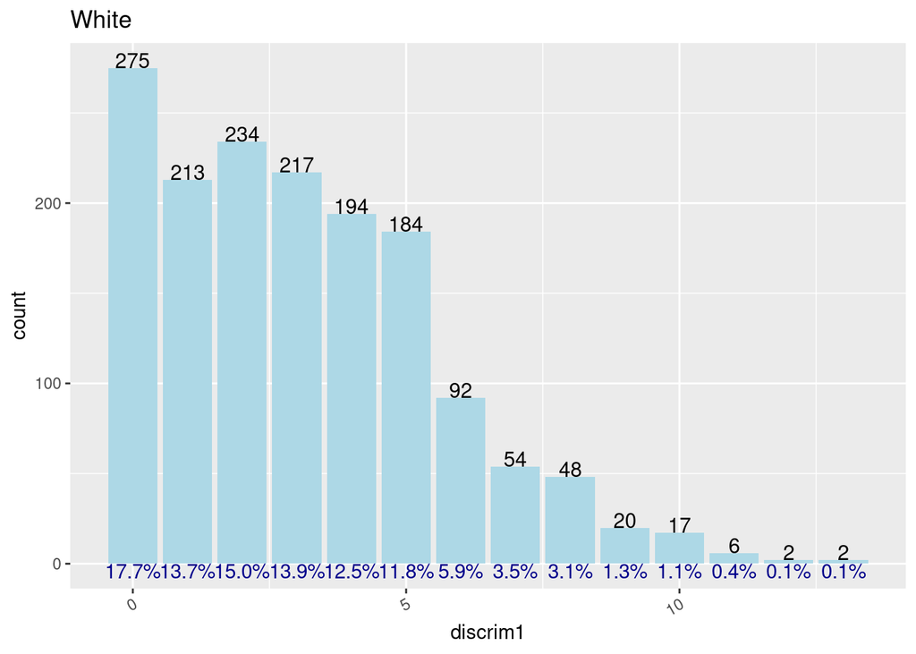

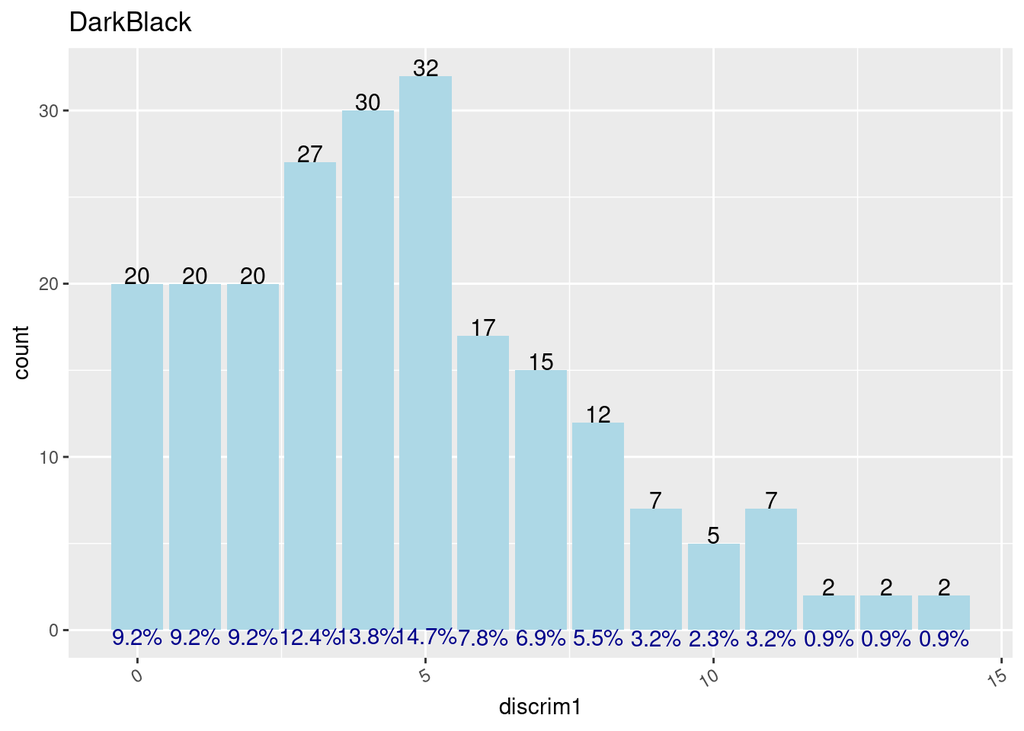

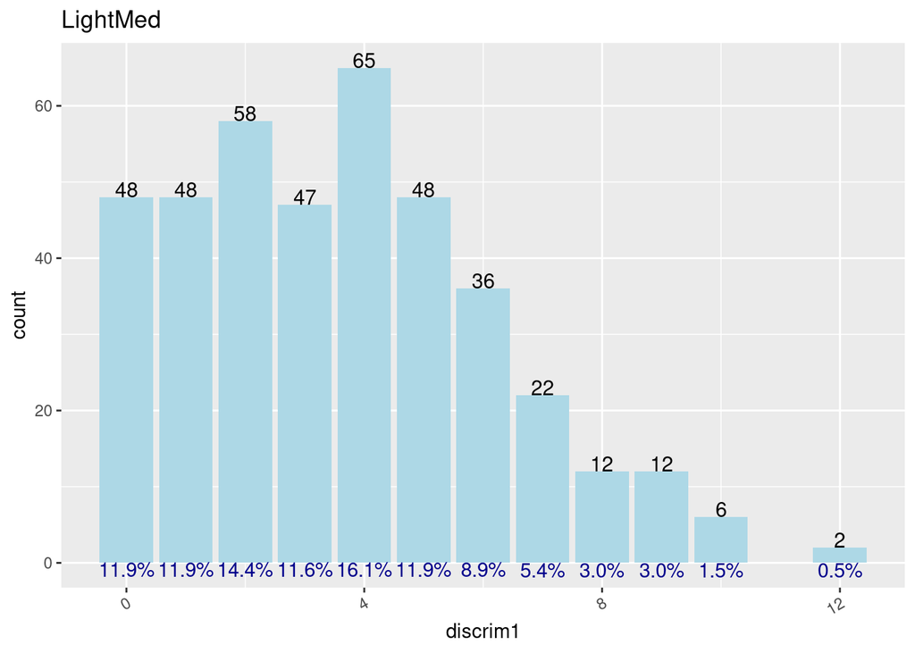

### discrim2 equals discrim1 if they feel the discrimination were due to race and ethnicity, otherwise 0

- discrimination due to race and ethnicity: H5MN6A==1 (ancestry or national origin) or H5MN6D==1(race)
- discrim2 ==0 : either they do not feel any discrimination or they do not think the discrimination were due to race and ethnicity

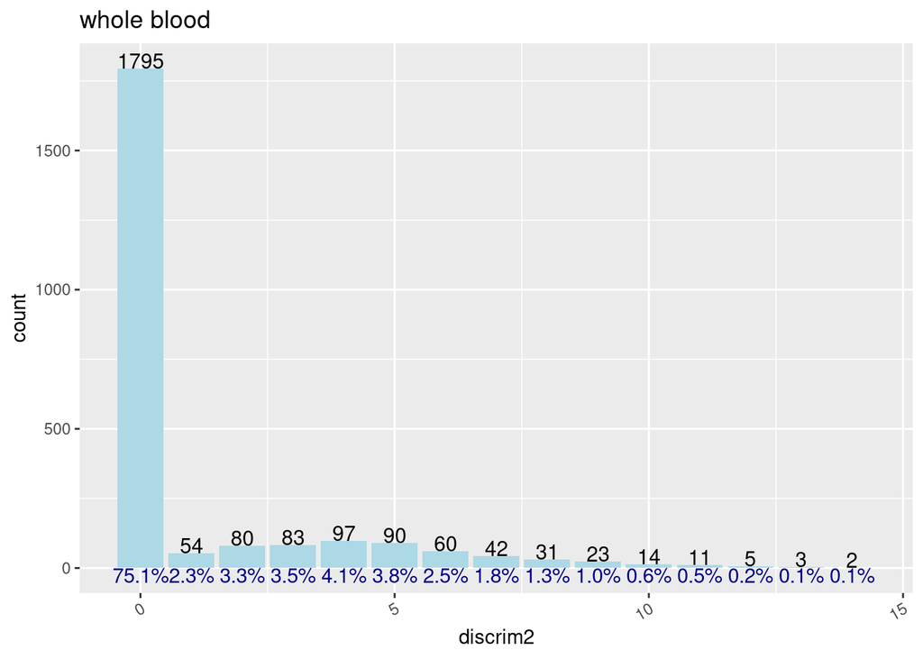

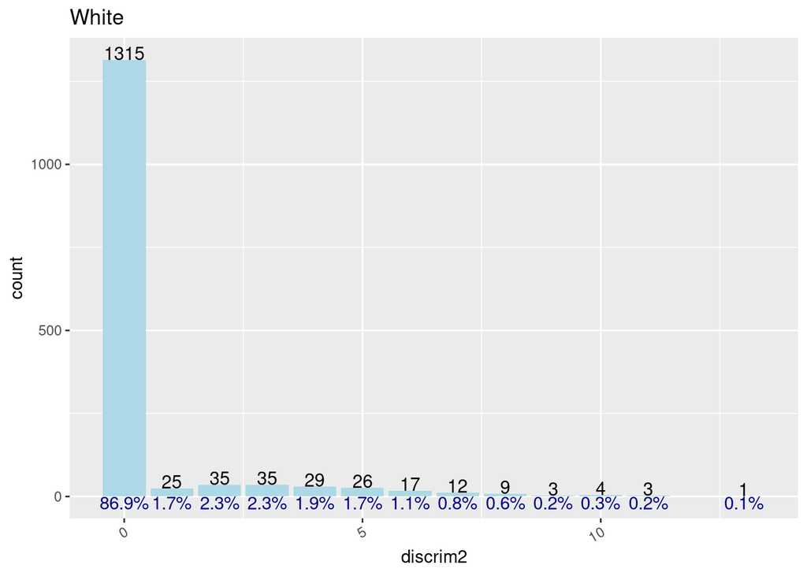

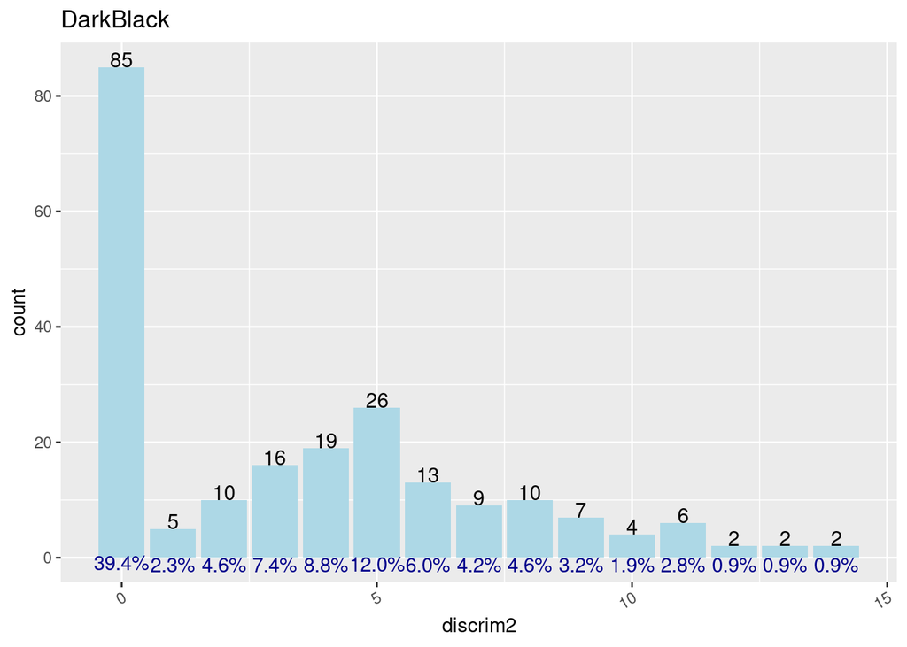

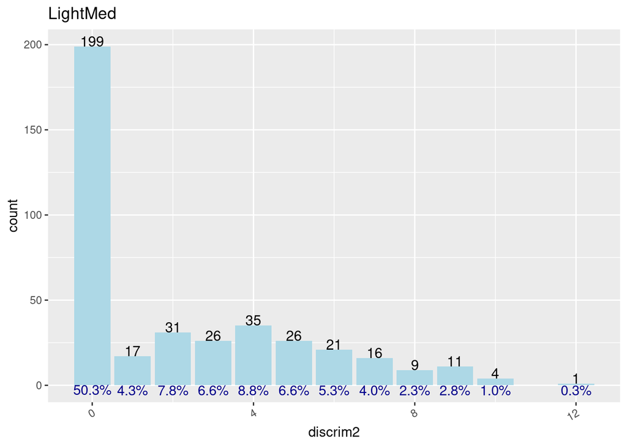

### totdiscrim1 is the sum of H5MN5[A-E] and H5MN7(binary)

- here H5MN5[A-E] are binarized: 0 for never and rarely, 1 for sometimes and often

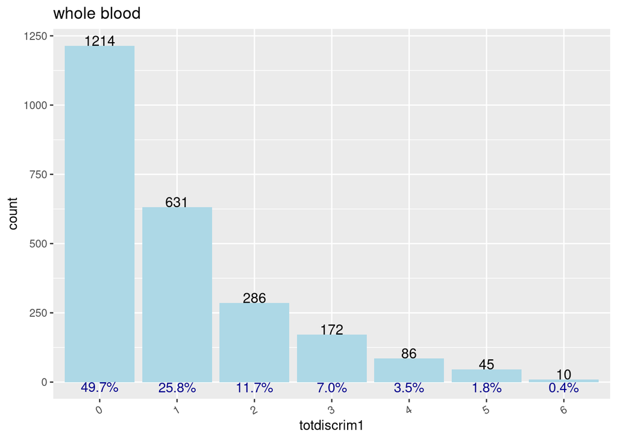

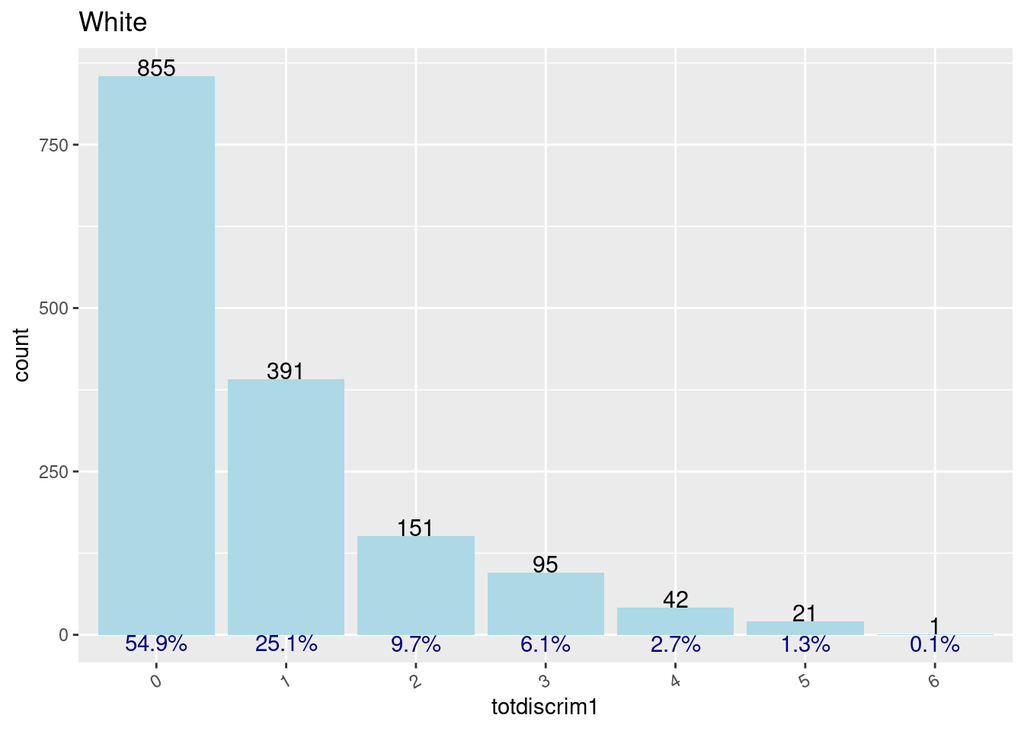

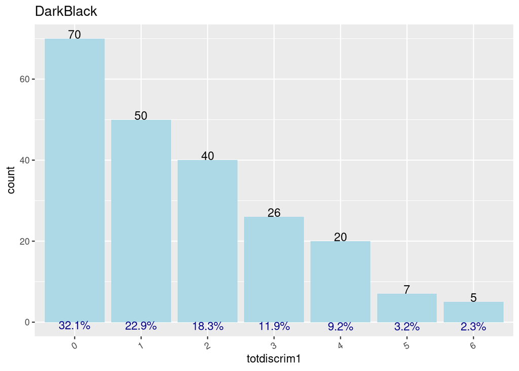

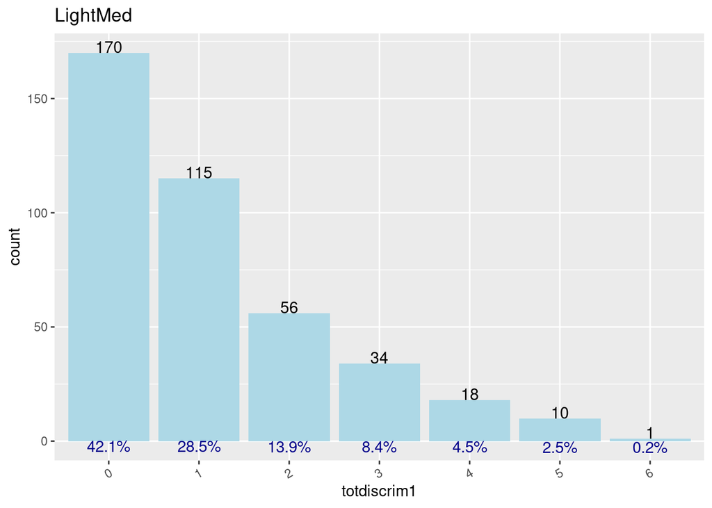

### totdiscrim2 equals totdiscrim1 if they feel the discrimination were due to race and ethnicity, otherwise 0

- discrimination due to race and ethnicity: H5MN6A==1 (ancestry or national origin) or H5MN6D==1(race)
- discrim2 ==0 : either they do not feel any discrimination or they do not think the discrimination were due to race and ethnicity

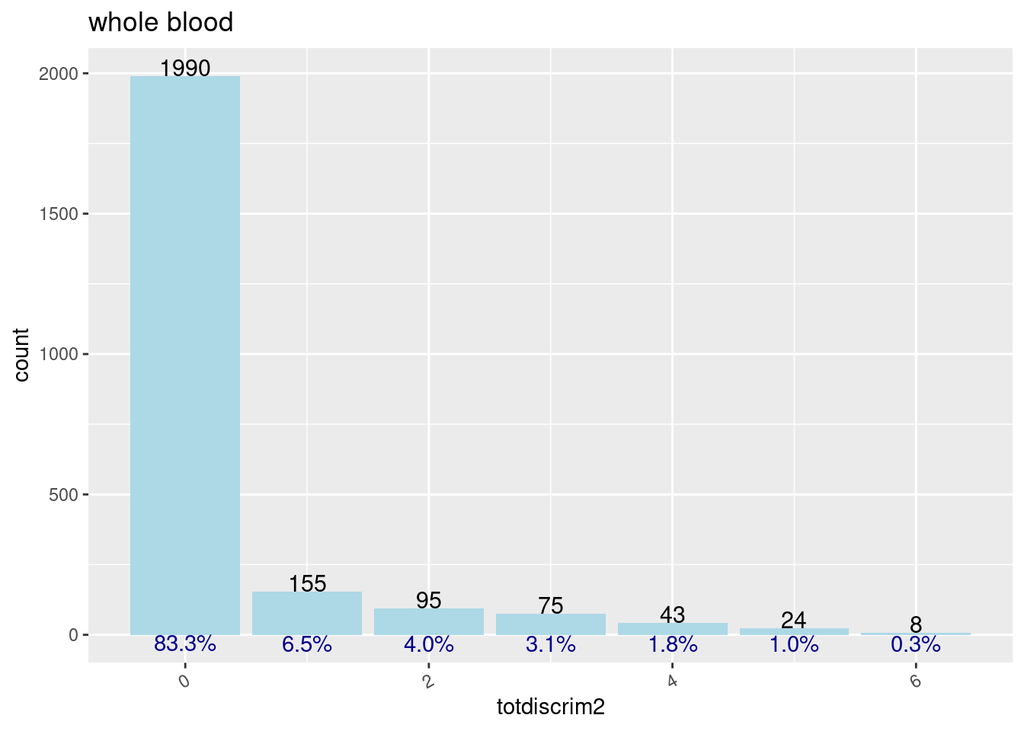

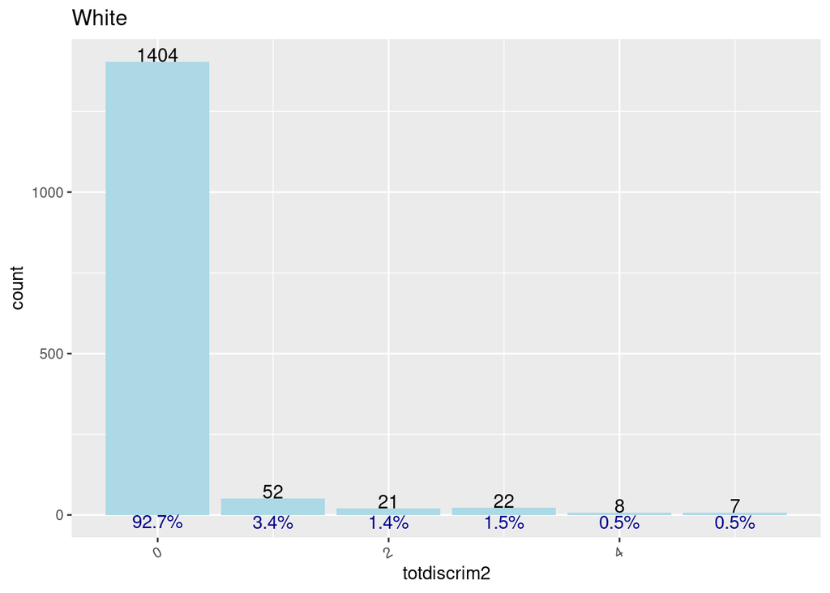

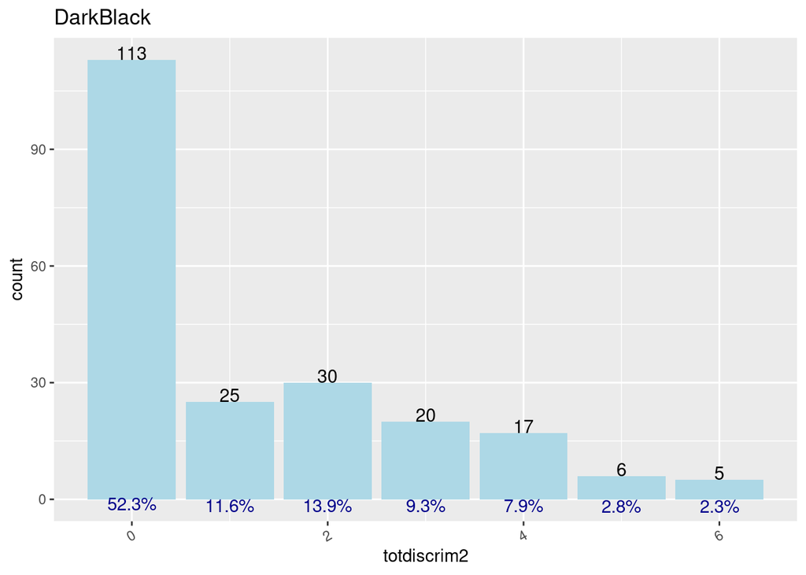

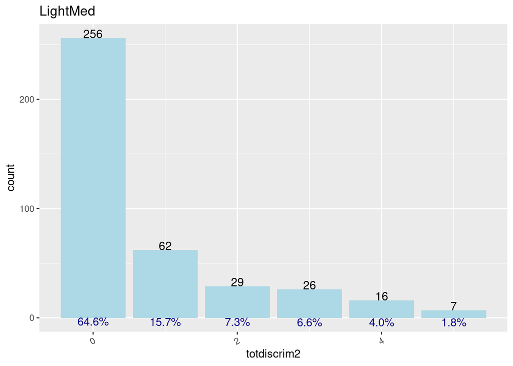

### countdiscrimwhy is created: if totdiscrim1>0, sum “H5MN6[A-L]” (reasons of discrimination)

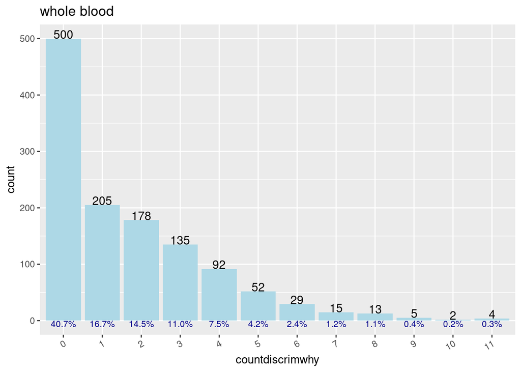

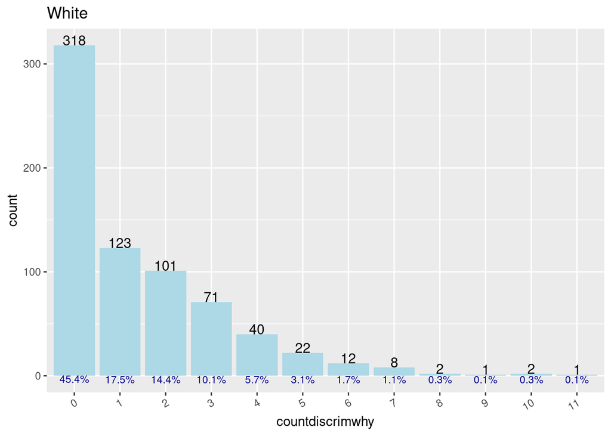

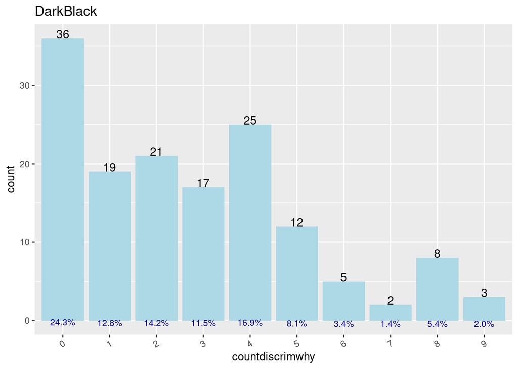

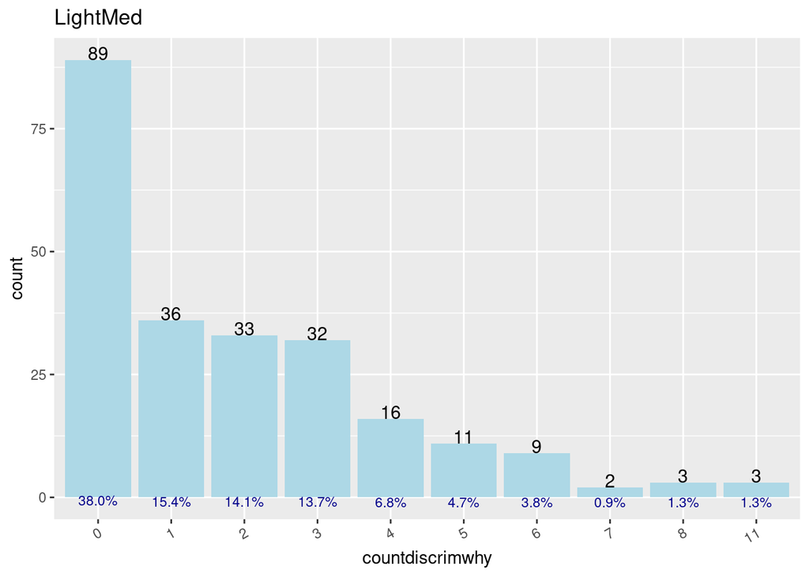